# Human Activity Recognition

### Executive Summary

This project Uses data from accelerometers on the belt, forearm, arm, and dumbell from 6 independent participants in an experiment. They were asked to perform barbell lifts correctly and incorrectly in 5 different ways. The goal of this project is to predict the manner in which the participants performed the exercise. For more information, please see http://groupware.les.inf.puc-rio.br/har.

### Loading and Splitting the data set(s)

```r
library(caret)
library(randomForest)
```

```r
urlTrainData = "https://d396qusza40orc.cloudfront.net/predmachlearn/pml-training.csv"
dataDirectory = "data"
sourceData = file.path(dataDirectory,"StormData.csv.bz2")
loadData = function(url, filename) {
  if (!file.exists(filename)) {
    download.file(url, filename, method = "curl", mode = "w")
    dateDownloaded <- date()
    if (!file.exists(filename)) {
      stop(paste("Unable to download file from:",url))
    }
  }
  return(read.csv(filename, strip.white=TRUE))
}
train_org = loadData(urlTrainData,"pml-training.csv")
row_index = createDataPartition(y=train_org$classe, p=.7, list=F)
train = train_org[row_index,]
validate = train_org[-row_index,]
```

### Variable Selection and Model Fit

The best solution to developing a model would be to hypothesis about all of the 159 variables in the training set by trolling through the data dictionary. This would have included learning more about the measurement devices used to generate this data, theory around proper exercise techniques, consulting with subject matter experts in the field, etc. However, in a 4 week MOOC this simply is not practical so an alternative method is used for this report.

The first step is to identify which variables would make good predictors. To somewhat automate this process, we can determine which variables produce minimal information gain and drop them from the training set which will be used to construct the prediction formula. To do this, we first find variables which have *near zero variance*, since such a small variance in the data would not provide us much information about the response variable. Then union those variables with all variables where *over 50% of the sampled data is NA*, since there is not a significant amount of collected data for these variables they will not be able to provide much information about the response variable. Finally, inspect the remaining variables and *cross reference with the data dictionary* to determine which data types would make good predictors.

```r
zero = nearZeroVar(train_org)
nas = which(as.numeric(colSums(is.na(train_org))/nrow(train_org)) > .5)
col_index = -sort(unique(c(zero,nas)))
train = train_org[,col_index]
names(train)
```

```
##  [1] "X"                    "user_name"            "raw_timestamp_part_1"
##  [4] "raw_timestamp_part_2" "cvtd_timestamp"       "num_window"
##  [7] "roll_belt"            "pitch_belt"           "yaw_belt"
## [10] "total_accel_belt"     "gyros_belt_x"         "gyros_belt_y"
## [13] "gyros_belt_z"         "accel_belt_x"         "accel_belt_y"
## [16] "accel_belt_z"         "magnet_belt_x"        "magnet_belt_y"
## [19] "magnet_belt_z"        "roll_arm"             "pitch_arm"
## [22] "yaw_arm"              "total_accel_arm"      "gyros_arm_x"
## [25] "gyros_arm_y"          "gyros_arm_z"          "accel_arm_x"
## [28] "accel_arm_y"          "accel_arm_z"          "magnet_arm_x"
## [31] "magnet_arm_y"         "magnet_arm_z"         "roll_dumbbell"
## [34] "pitch_dumbbell"       "yaw_dumbbell"         "total_accel_dumbbell"
## [37] "gyros_dumbbell_x"     "gyros_dumbbell_y"     "gyros_dumbbell_z"
## [40] "accel_dumbbell_x"     "accel_dumbbell_y"     "accel_dumbbell_z"
## [43] "magnet_dumbbell_x"    "magnet_dumbbell_y"    "magnet_dumbbell_z"
## [46] "roll_forearm"         "pitch_forearm"        "yaw_forearm"
## [49] "total_accel_forearm"  "gyros_forearm_x"      "gyros_forearm_y"
## [52] "gyros_forearm_z"      "accel_forearm_x"      "accel_forearm_y"
## [55] "accel_forearm_z"      "magnet_forearm_x"     "magnet_forearm_y"
## [58] "magnet_forearm_z"     "classe"
```

After performing the first two reduction techniques, there are a few remaining variables which are suspect and would not tell us much about the response variable. We learned what these variables are by checking the data dictionary and/or manually inspecting the values contained within each to make a judgement call. If we were to simply include these variables, it would subject the model to over-fitting with samples from the training set. So we set them to NULL in the training set to remove them from our model.

```r
train$X = NULL
train$raw_timestamp_part_1 = NULL
train$raw_timestamp_part_2 = NULL
train$num_window = NULL
train$user_name = NULL
train$cvtd_timestamp = NULL
```

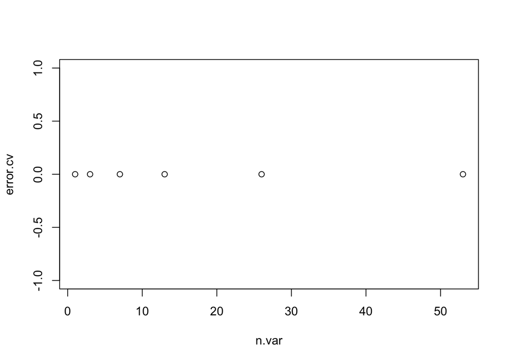

```r
cv = rfcv(train,train$classe,cv.fold=2)
with(cv, plot(n.var, error.cv))
```

```r
model = randomForest(classe~.,data=train,ntree=500)
```

```r
prd = predict(model,validate)
accuracy = list(cci=sum(validate$classe==prd)/nrow(validate))
table(prd,validate$classe)
```

```
##
## prd    A    B    C    D    E
##   A 1674    0    0    0    0
##   B    0 1139    0    0    0
##   C    0    0 1026    0    0
##   D    0    0    0  964    0
##   E    0    0    0    0 1082
```